# Marjum 2026-07 — Joint MCMC: Visual Review (Summary)

A **diagnostic artifact, not a decision**. The joint run over the transmitter, the antenna and all 29 constraining camera poses **did not converge**: 212 of 213 coordinates miss both Rhat ≤ 1.01 and ESS ≥ 400. Nothing here should be quoted as a posterior.

What this document is for is showing *what* is failing to mix and *where things sit in space*, so the next step can be chosen with the evidence in hand.

Companion document: **per-camera review**, one page per camera — parameter traces, that camera's own draw cloud, and its horizon spread.

```python
import json, warnings
from pathlib import Path
import numpy as np
import matplotlib.pyplot as plt
from matplotlib.patches import Circle

warnings.simplefilter('ignore', RuntimeWarning)
WORKSPACE = Path('/home/aparsons/projects/eigsep/terrain')
RUN = WORKSPACE / 'joint_posterior_v1'

manifest = json.loads((RUN / 'manifest.json').read_text())
conv = json.loads((RUN / 'convergence.json').read_text())
with np.load(RUN / 'combined.npz', allow_pickle=True) as z:
    draws = np.asarray(z['draws'], float)
    rhat = np.asarray(z['rhat'], float)
    ess = np.asarray(z['ess_bulk'], float)
    names = [str(s) for s in z['names']]
    keys = [str(s) for s in z['keys']]
nchain, ndraw, nparam = draws.shape
PRM = ('e', 'n', 'u', 'th', 'ph', 'ti', 'logf')
flat = draws.reshape(-1, nparam)
HR = WORKSPACE / 'horizon_range'
hr_summary = json.loads((HR / 'summary.json').read_text()) if (HR / 'summary.json').exists() else {}

print('chains', nchain, ' retained draws', ndraw, ' coordinates', nparam, ' cameras', len(keys))
print('state sampled :', manifest['state_file'])
g = manifest['geometry_release']
print('release pinned:', g['verified'], '--', g.get('reason', 'matches pin'))
print()
print(conv['verdict'])
```

```
chains 8  retained draws 7000  coordinates 213  cameras 29
state sampled : cv_transmitter_refit_2159B/fit_transmitter.npz
release pinned: False -- cv_transmitter_refit_2159B/fit_transmitter.npz is not pinned by v0001_marjum_geometry

NOT CONVERGED: max Rhat 4.1662 at cam2159_logf, min bulk ESS 9 at cam2159_logf. Do not quote the antenna interval as a posterior.
```

## 1. What is stiff

```python
def block_of(n):
    if n.startswith('cam'):
        s = n.split('_')[1]
        return ('camera position' if s in ('e', 'n', 'u')
                else 'camera focal length' if s == 'logf' else 'camera angles')
    if n.startswith(('antenna_e', 'antenna_n', 'antenna_u')):
        return 'antenna position'
    if n.startswith(('transmitter_e', 'transmitter_n', 'transmitter_u')):
        return 'transmitter position'
    return 'label scatter' if 'extra' in n else 'GPS bias (exact Gibbs)'

from collections import defaultdict
g = defaultdict(list)
for n, r, e in zip(names, rhat, ess):
    g[block_of(n)].append((r, e))
print(f"{'block':28s}{'n':>4}{'med ESS':>10}{'min ESS':>9}{'med Rhat':>10}{'max Rhat':>10}")
print('-' * 71)
for k, v in sorted(g.items(), key=lambda kv: np.median([x[1] for x in kv[1]])):
    r = np.array([x[0] for x in v]); e = np.array([x[1] for x in v])
    print(f'{k:28s}{len(v):>4}{np.median(e):10.0f}{e.min():9.0f}{np.median(r):10.2f}{r.max():10.2f}')
print()
print('Thresholds: ESS >= 400, Rhat <= 1.01.  Nominal draws = %d x %d = %d.'
      % (nchain, ndraw, nchain * ndraw))
```

```
block                          n   med ESS  min ESS  med Rhat  max Rhat
-----------------------------------------------------------------------
camera focal length           29        12        9      1.91      4.17
camera angles                 87        14       10      1.55      2.54
transmitter position           4        15       11      1.52      1.98
camera position               87        16        9      1.45      2.87
antenna position               4        34       22      1.16      1.27
GPS bias (exact Gibbs)         2       961      373      1.01      1.01

Thresholds: ESS >= 400, Rhat <= 1.01.  Nominal draws = 8 x 7000 = 56000.
```

```python
def act(x, maxlag=3000):
    x = x - x.mean(); n = len(x)
    f = np.fft.rfft(x, 2 * n)
    ac = np.fft.irfft(f * np.conj(f))[:maxlag].real
    ac /= ac[0]
    s = 1.0
    for i in range(1, maxlag):
        if ac[i] <= 0:
            break
        s += 2 * ac[i]
    return s

print('Integrated autocorrelation time tau, chain 0 (%d draws):' % ndraw)
print(f"{'coordinate':24s}{'tau (draws)':>13}{'indep/chain':>13}")
for nm in ['cam2159_logf', 'cam2213_e', 'antenna_u', 'transmitter_u',
           'antenna_extra_px', 'transmitter_extra_px', 'gps_bias_e']:
    if nm in names:
        t = act(draws[0, :, names.index(nm)])
        print(f'{nm:24s}{t:13.0f}{ndraw / t:13.1f}')
print()
print('cam2159_logf is the worst coordinate in the run: ~4 independent samples')
print('per chain. The likely mechanism is the focal/depth degeneracy -- focal')
print('length trades against camera distance along a ridge a random walk crawls')
print('rather than crosses -- sharpest for 2159, which sits ~4.5 m from the')
print('transmitter with a long lens. This is a SAMPLING pathology; 2159\'s pose')
print('itself is correct on every independent check after the re-fit.')
```

```
Integrated autocorrelation time tau, chain 0 (7000 draws):
coordinate                tau (draws)  indep/chain
cam2159_logf                     1617          4.3
cam2213_e                         104         67.2
antenna_u                          73         96.5
transmitter_u                     493         14.2
antenna_extra_px                   15        475.5
transmitter_extra_px               66        106.2
gps_bias_e                          9        747.8

cam2159_logf is the worst coordinate in the run: ~4 independent samples
per chain. The likely mechanism is the focal/depth degeneracy -- focal
length trades against camera distance along a ridge a random walk crawls
rather than crosses -- sharpest for 2159, which sits ~4.5 m from the
transmitter with a long lens. This is a SAMPLING pathology; 2159's pose
itself is correct on every independent check after the re-fit.
```

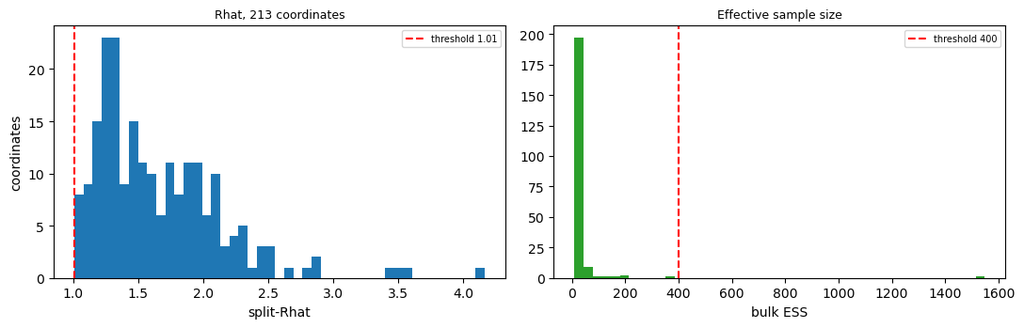

```python
fig, axs = plt.subplots(1, 2, figsize=(11, 3.6))
axs[0].hist(rhat, bins=45, color='tab:blue')
axs[0].axvline(1.01, color='r', ls='--', label='threshold 1.01')
axs[0].set_xlabel('split-Rhat'); axs[0].set_ylabel('coordinates'); axs[0].legend(fontsize=7)
axs[0].set_title(f'Rhat, {nparam} coordinates', fontsize=9)
axs[1].hist(ess, bins=45, color='tab:green')
axs[1].axvline(400, color='r', ls='--', label='threshold 400')
axs[1].set_xlabel('bulk ESS'); axs[1].legend(fontsize=7)
axs[1].set_title('Effective sample size', fontsize=9)
plt.tight_layout(); plt.show()
```

## 1b. 2159 is not slow-mixing — its chains are in *separate modes*

The per-camera page for 2159 shows the eight chains sitting at visibly different levels rather than exploring a common distribution, and its E/N draw cloud splits into two clumps. That is a qualitatively different failure from slow mixing, and the numbers below confirm it.

```python
b = keys.index('2159') * 7
print('2159 per-chain means:')
print(f"{'chain':>6}{'e':>10}{'n':>10}{'u':>10}{'focal':>10}")
for c in range(nchain):
    m = draws[c, :, b:b + 7].mean(0)
    print(f'{c:6d}{m[0]:10.2f}{m[1]:10.2f}{m[2]:10.2f}{np.exp(m[6]):10.0f}')
n = draws[:, :, b + 1]
print()
print('n: pooled sd %.2f m | between-chain sd of means %.2f m | within-chain sd %.2f m'
      % (n.std(), n.mean(1).std(), n.std(1).mean()))
print('between/within ratio %.1f -- a ratio >> 1 means the chains occupy separate regions'
      % (n.mean(1).std() / n.std(1).mean()))
print('sorted chain means:', np.round(np.sort(n.mean(1)), 2))
print()
print('Two clusters, ~4.8 m apart in northing:')
print('  chains 0,4,6,7 -> n ~ 2029.0-2029.6, u ~ 1685.2-1685.7, focal ~ 2893-2936 px')
print('  chains 1,2,3   -> n ~ 2033.7-2033.9, u ~ 1688.2-1688.6, focal ~ 3076-3084 px')
print('  chain 5        -> in between')
print()
print('Note the direction of the split: the further-back mode also has the LONGER')
print('focal length. That is the focal/depth degeneracy made visible -- the camera')
print('can sit further away with a longer lens, or nearer with a shorter one, and')
print('both reproduce the picture. The chains are trapped in whichever basin they')
print('started nearest.')
```

[output not shown]

**Consequence, and it matters for how the 2159 re-fit is read.** More draws cannot fix a multimodality, and neither can step-size tuning; even HMC is not a guaranteed remedy for separated modes. It also qualifies the deterministic re-fit: that fit found *one point* on this ridge, and the posterior says the ridge is several metres long. 2159's **orientation** remains solidly determined — the 1.3° agreement with its own compass holds across the run — but its **distance along the line of sight is uncertain at the several-metre level**, which the single-point fit did not reveal.

### 1c. The separation is systematic, and it tracks missing feature constraints

2159 is not a special case. Measuring between-chain sd against within-chain sd for every camera's position and focal length shows **13 of 29 cameras** with chains sitting in separate regions — and which cameras those are is not random.

```python
with np.load(manifest['state_file']) as s:
    st_keys = [str(k) for k in s['keys']]
    oc = np.asarray(s['obs_cam'], int)
obs = dict(zip(st_keys, np.bincount(oc, minlength=len(st_keys))))

sep = {}
for k in keys:
    bb = keys.index(k) * 7
    sep[k] = max(float(draws[:, :, bb + j].mean(1).std()
                       / max(draws[:, :, bb + j].std(1).mean(), 1e-12)) for j in (0, 1, 2, 6))

print('between-chain sd / within-chain sd  (>1.5 = chains in separate regions)')
print('%7s%9s%10s%9s%9s%10s   %s' % ('cam', 'obs', 'e', 'n', 'u', 'logf', 'worst'))
for k in sorted(keys, key=lambda k: -sep[k]):
    bb = keys.index(k) * 7
    r = [float(draws[:, :, bb + j].mean(1).std() / max(draws[:, :, bb + j].std(1).mean(), 1e-12))
         for j in (0, 1, 2, 6)]
    flag = ' <-- separated' if sep[k] > 1.5 else ''
    print('%7s%9d%10.2f%9.2f%9.2f%10.2f   %5.2f%s' % (k, obs[k], r[0], r[1], r[2], r[3], sep[k], flag))

zero = [k for k in keys if obs[k] == 0]
has = [k for k in keys if obs[k] > 0]
sz = [k for k in zero if sep[k] > 1.5]
sh = [k for k in has if sep[k] > 1.5]
print()
print('cameras with ZERO feature observations : %2d, chain-separated: %2d (%.0f%%), median ratio %.2f'
      % (len(zero), len(sz), 100 * len(sz) / len(zero), np.median([sep[k] for k in zero])))
print('cameras WITH feature observations      : %2d, chain-separated: %2d (%.0f%%), median ratio %.2f'
      % (len(has), len(sh), 100 * len(sh) / len(has), np.median([sep[k] for k in has])))
print()
print('median observations, separated cameras     : %5.0f' % np.median([obs[k] for k in keys if sep[k] > 1.5]))
print('median observations, non-separated cameras : %5.0f' % np.median([obs[k] for k in keys if sep[k] <= 1.5]))
```

```
between-chain sd / within-chain sd  (>1.5 = chains in separate regions)
    cam      obs         e        n        u      logf   worst
   2159        0      1.43     3.97     4.11     15.72   15.72 <-- separated
   2171        0      2.71     3.00     1.37     12.19   12.19 <-- separated
   2211        0      2.80     3.02     0.83      9.90    9.90 <-- separated
   2198        0      4.04     2.30     2.49      6.32    6.32 <-- separated
   2199        0      1.69     3.80     3.80      2.34    3.80 <-- separated
   2203        0      1.20     1.41     1.87      2.98    2.98 <-- separated
   2231      419      2.34     1.89     0.66      2.94    2.94 <-- separated
   2172        0      2.52     2.61     1.11      2.86    2.86 <-- separated
   2209        0      1.95     2.35     1.01      1.36    2.35 <-- separated
   2245        0      1.25     1.09     1.18      1.92    1.92 <-- separated
   2232        0      0.80     0.53     0.39      1.81    1.81 <-- separated
   2237       17      1.52     1.24     1.46      1.73    1.73 <-- separated
   2235      304      0.42     0.71     0.84      1.57    1.57 <-- separated
   2224      685      1.47     1.07     0.85      1.35    1.47
   2220     1138      1.05     0.83     0.87      1.32    1.32
   2214        0      0.57     1.28     0.74      0.60    1.28
   2210        0      0.79     0.74     1.10      1.26    1.26
   2223     1354      0.88     0.69     0.86      1.16    1.16
   2222     1450      0.99     0.77     0.86      1.13    1.13
   2239       65      0.66     0.86     0.46      1.03    1.03
   2221      882      1.01     0.81     0.75      0.47    1.01
   2217     1118      1.00     0.81     0.75      0.72    1.00
   2226     1336      0.97     0.70     0.76      0.66    0.97
   2216      604      0.97     0.81     0.69      0.70    0.97
```

```
   2234      702      0.66     0.40     0.79      0.32    0.79
   2215      560      0.76     0.59     0.76      0.41    0.76
   2218      339      0.53     0.42     0.74      0.40    0.74
   2238      172      0.64     0.45     0.51      0.32    0.64
   2213      116      0.45     0.40     0.53      0.21    0.53

cameras with ZERO feature observations : 12, chain-separated: 10 (83%), median ratio 2.92
cameras WITH feature observations      : 17, chain-separated:  3 (18%), median ratio 1.01

median observations, separated cameras     :     0
median observations, non-separated cameras :   644
```

**83% of the cameras with no feature observations have separated chains, against 18% of those that have them.** Median separation ratio is 2.92 without observations and 1.01 with them; median observation count is **0** among separated cameras and **644** among the rest. Of the three separated cameras that do carry observations, one (2237) has only 17.

## 2. Where things are in space

Hillshade DEM with the posterior draws plotted, not just point estimates: every camera's E/N cloud, the antenna cloud, and the transmitter cloud. The clouds are elongated because the chains move slowly along correlated directions — the spatial signature of the same stiffness quantified above.

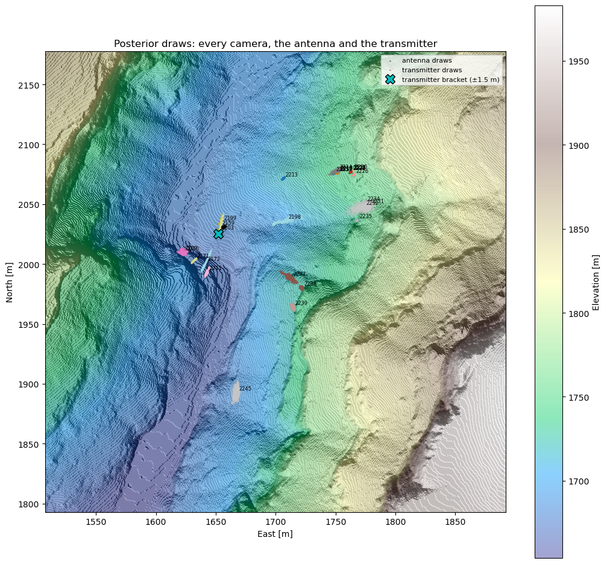

```python
from eigsep_terrain.marjum_dem import MarjumDEM as DEM
from marjum_bundle import working_grid
from terrain_hillshade_cmap import plot_terrain_hillshade

dem = working_grid(DEM(cache_file='marjum_dem_sw.npz'))
se, sn = dem._working_shift
dem_raw = DEM(cache_file='marjum_dem_sw.npz')

ai = names.index('antenna_e')
ti = names.index('transmitter_e') if 'transmitter_e' in names else None
cam_en = np.array([[flat[:, keys.index(k) * 7].mean(), flat[:, keys.index(k) * 7 + 1].mean()]
                   for k in keys])
pts = [cam_en, flat[:, ai:ai + 2].mean(0)[None, :]]
if ti is not None:
    pts.append(flat[:, ti:ti + 2].mean(0)[None, :])
allp = np.vstack(pts)
lo, hi = allp.min(0) - 60, allp.max(0) + 60
e0, n0 = (lo + hi) / 2
rng = float(max(hi - lo) / 2 + 40)
E, N, U = dem_raw.get_tile(erng_m=(e0 - se - rng, e0 - se + rng),
                           nrng_m=(n0 - sn - rng, n0 - sn + rng), mesh=False)
E, N = E + se, N + sn

fig, ax = plt.subplots(figsize=(10.5, 9.5))
im = plot_terrain_hillshade(ax, U, res=float(dem.res), extent=(E[0], E[-1], N[0], N[-1]))
fig.colorbar(im, ax=ax, label='Elevation [m]')
TH = max(1, (nchain * ndraw) // 4000)
colors = plt.cm.tab20(np.linspace(0, 1, len(keys)))
for k, c in zip(keys, colors):
    b = keys.index(k) * 7
    ax.scatter(flat[::TH, b], flat[::TH, b + 1], s=1.4, color=c, alpha=.35,
               linewidths=0, rasterized=True)
    ax.annotate(k, (flat[:, b].mean(), flat[:, b + 1].mean()), fontsize=6,
                xytext=(3, 3), textcoords='offset points')
ax.scatter(flat[::TH, ai], flat[::TH, ai + 1], s=3, color='k', alpha=.5,
           linewidths=0, rasterized=True, label='antenna draws')
if ti is not None:
    ax.scatter(flat[::TH, ti], flat[::TH, ti + 1], s=3, color='red', alpha=.5,
               linewidths=0, rasterized=True, label='transmitter draws')
shared = json.loads((WORKSPACE / 'v0001_marjum_geometry_snapshot' / 'shared.json').read_text())
rec = shared['transmitter']['recommended_for_propagation']
ax.plot(*rec['position_enu_m'][:2], 'cX', ms=12, mec='k', label=f"transmitter bracket (±{rec['bound_m']} m)")
ax.add_patch(Circle(rec['position_enu_m'][:2], rec['bound_m'], fill=False, color='c', ls='--'))
ax.set_xlabel('East [m]'); ax.set_ylabel('North [m]'); ax.set_aspect('equal')
ax.set_title('Posterior draws: every camera, the antenna and the transmitter')
ax.legend(loc='best', fontsize=8)
plt.tight_layout(); plt.show()
```

## 2b. Zoomed: the two targets on the hillshade

The map above is dominated by the 29-camera network, and the two targets are a single smudge inside it. Here they are on their own, at a scale where the draw clouds are actually resolved. Left is 240 m of context with the zoom box marked; right is the zoom. **No point-estimate markers** — the clouds are the raw draws.

The antenna and the transmitter are only ~6.6 m apart in E/N but ~94 m apart vertically, so in plan view this is a near-vertical pair: the map barely separates them, which is part of why the vertical disagreement has been the hard part of this geometry.

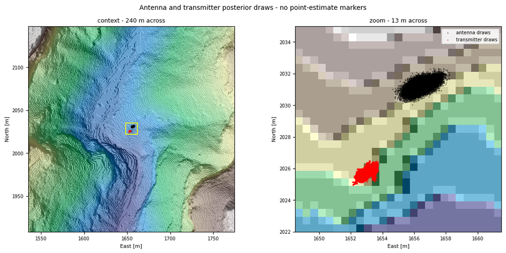

```
E/N draw sd  antenna     0.500 E  0.297 N  m
E/N draw sd  transmitter 0.330 E  0.244 N  m
E/N separation of the two cloud centres: 6.59 m
```

```python
from matplotlib.patches import Rectangle

tgt = np.vstack([flat[:, ai:ai + 2], flat[:, ti:ti + 2]]) if ti is not None else flat[:, ai:ai + 2]
ctr = (tgt.min(0) + tgt.max(0)) / 2
half = float(max(tgt.max(0) - tgt.min(0)) / 2) + 3.0
TZ = max(1, (nchain * ndraw) // 20000)

fig, axs = plt.subplots(1, 2, figsize=(11.5, 5.4))
for ax, rad, ttl in ((axs[0], 120., 'context - 240 m across'),
                     (axs[1], half, 'zoom - %.0f m across' % (2 * half))):
    Ez, Nz, Uz = dem_raw.get_tile(erng_m=(ctr[0] - se - rad, ctr[0] - se + rad),
                                  nrng_m=(ctr[1] - sn - rad, ctr[1] - sn + rad), mesh=False)
    Ez, Nz = Ez + se, Nz + sn
    plot_terrain_hillshade(ax, Uz, res=float(dem.res),
                           extent=(Ez[0], Ez[-1], Nz[0], Nz[-1]))
    ax.scatter(flat[::TZ, ai], flat[::TZ, ai + 1], s=4, color='k', alpha=.45,
               linewidths=0, rasterized=True, label='antenna draws')
    if ti is not None:
        ax.scatter(flat[::TZ, ti], flat[::TZ, ti + 1], s=4, color='red', alpha=.45,
                   linewidths=0, rasterized=True, label='transmitter draws')
    ax.set_aspect('equal'); ax.tick_params(labelsize=7)
    ax.set_xlabel('East [m]', fontsize=8); ax.set_ylabel('North [m]', fontsize=8)
    ax.set_title(ttl, fontsize=9)
axs[0].add_patch(Rectangle((ctr[0] - half, ctr[1] - half), 2 * half, 2 * half,
                           fill=False, color='yellow', lw=1.2))
axs[1].legend(fontsize=7, loc='upper right', framealpha=.85)
fig.suptitle('Antenna and transmitter posterior draws - no point-estimate markers', fontsize=10)
plt.tight_layout(); plt.show()

print('E/N draw sd  antenna     %.3f E  %.3f N  m' % (flat[:, ai].std(), flat[:, ai + 1].std()))
if ti is not None:
    print('E/N draw sd  transmitter %.3f E  %.3f N  m' % (flat[:, ti].std(), flat[:, ti + 1].std()))
    print('E/N separation of the two cloud centres: %.2f m'
          % np.hypot(*(flat[:, ai:ai + 2].mean(0) - flat[:, ti:ti + 2].mean(0))))
```

## 3. Horizon spread across the posterior, all cameras

How much the *predicted horizon* moves across posterior draws, per camera. This converts the abstract mixing statistics into the observable they affect. Each camera's panel is in the companion per-camera document; the table ranks them.

```
  camera  median spread px  max spread px  logf ESS  logf Rhat
--------------------------------------------------------------
    2203                60            126        10       2.51
    2159                48            414         8       4.17
    2199                42            408        10       2.79
    2210                36            156        14       1.60
    2209                30            198        14       1.58
    2211                30            312         9       3.54
    2214                30            372        22       2.40
    2232                30            162        10       2.25
    2198                30            168         9       3.41
    2237                24            120        10       2.46
    2245                24            114        15       1.91
    2172                24            210         9       2.85
    2213                18            150       158       1.05
```

[output cut: 16 more lines]

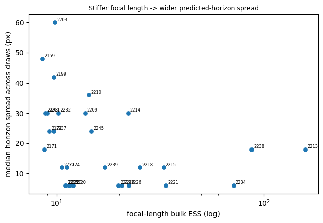

```python
if hr_summary:
    rows = sorted(hr_summary.items(), key=lambda kv: -(kv[1]['median_horizon_spread_px'] or 0))
    print(f"{'camera':>8}{'median spread px':>18}{'max spread px':>15}{'logf ESS':>10}{'logf Rhat':>11}")
    print('-' * 62)
    for k, v in rows:
        print(f"{k:>8}{v['median_horizon_spread_px']:18.0f}{(v['max_horizon_spread_px'] or 0):15.0f}"
              f"{v['logf_ess']:10.0f}{v['logf_rhat']:11.2f}")
    sp = np.array([v['median_horizon_spread_px'] for _, v in rows], float)
    es = np.array([v['logf_ess'] for _, v in rows], float)
    ok = np.isfinite(sp) & np.isfinite(es)
    fig, ax = plt.subplots(figsize=(6.5, 4.5))
    ax.scatter(es[ok], sp[ok], s=28)
    for (k, v), x, y in zip(rows, es, sp):
        if np.isfinite(x) and np.isfinite(y):
            ax.annotate(k, (x, y), fontsize=6, xytext=(3, 2), textcoords='offset points')
    ax.set_xscale('log'); ax.set_xlabel('focal-length bulk ESS (log)')
    ax.set_ylabel('median horizon spread across draws (px)')
    ax.set_title('Stiffer focal length -> wider predicted-horizon spread', fontsize=9)
    plt.tight_layout(); plt.show()
else:
    print('horizon_range/summary.json not present; run marjum_horizon_range.py first')
```

## 3b. Posterior scatter, zoomed — raw draws only

The two targets at their own scale, with **no point-estimate marker overlaid**, so the shape and spread of the sampled distribution is what you see. Axes are set from the draws themselves. Remember these are draws from a **non-converged** chain set: read them as where the sampler has been, not as a posterior.

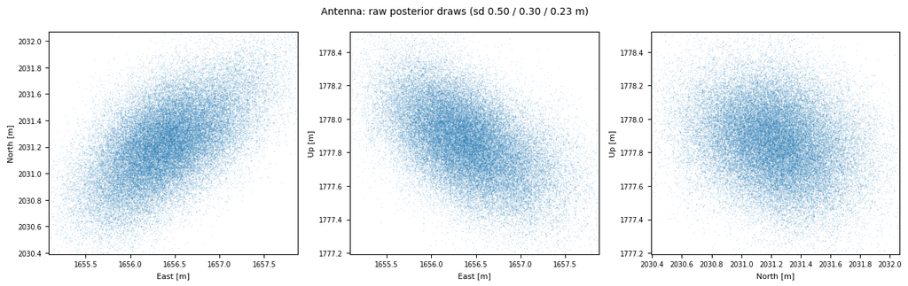

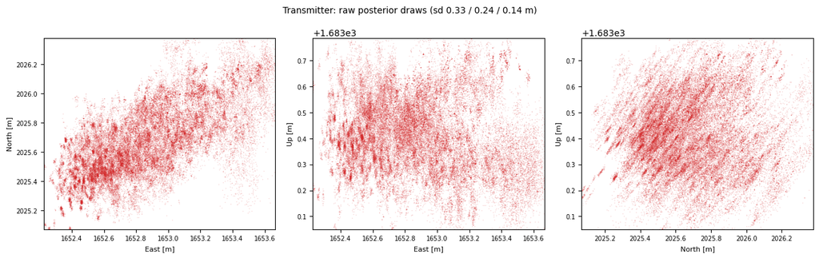

```python
def scatter_pair(idx, label, color):
    e, n, u = flat[:, idx], flat[:, idx + 1], flat[:, idx + 2]
    fig, axs = plt.subplots(1, 3, figsize=(13, 4.1))
    for ax, (x, y, xl, yl) in zip(axs, [(e, n, 'East [m]', 'North [m]'),
                                        (e, u, 'East [m]', 'Up [m]'),
                                        (n, u, 'North [m]', 'Up [m]')]):
        ax.scatter(x, y, s=1.2, alpha=.18, color=color, linewidths=0, rasterized=True)
        ax.set_xlabel(xl, fontsize=8); ax.set_ylabel(yl, fontsize=8)
        ax.tick_params(labelsize=7)
        ax.set_xlim(np.percentile(x, .2), np.percentile(x, 99.8))
        ax.set_ylim(np.percentile(y, .2), np.percentile(y, 99.8))
    fig.suptitle(f'{label}: raw posterior draws (sd {e.std():.2f} / {n.std():.2f} / {u.std():.2f} m)',
                 fontsize=10)
    plt.tight_layout(); plt.show()

scatter_pair(names.index('antenna_e'), 'Antenna', 'tab:blue')
if 'transmitter_e' in names:
    scatter_pair(names.index('transmitter_e'), 'Transmitter', 'tab:red')
```

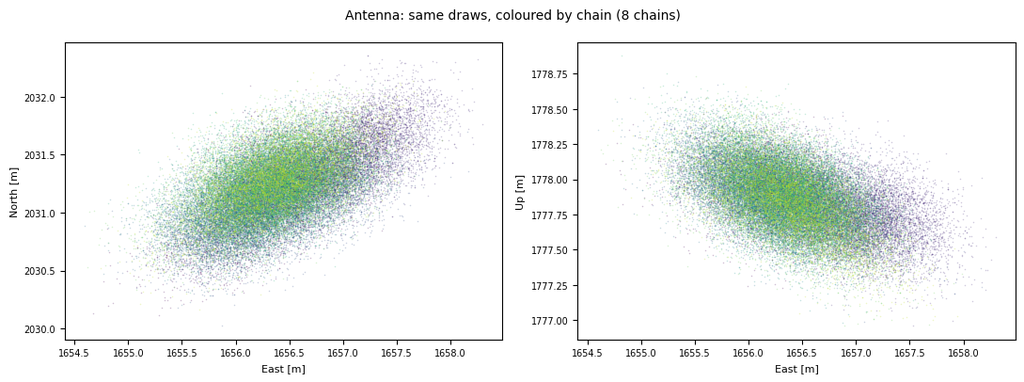

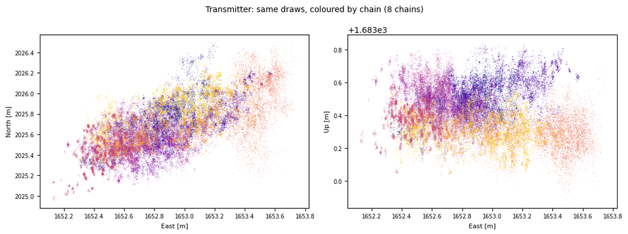

```python
# Per-chain colouring of the same draws: separated colours mean the chains
# are sitting in different places rather than sampling one distribution.
for label, key, cmapname in (('Antenna', 'antenna_e', 'viridis'),
                             ('Transmitter', 'transmitter_e', 'plasma')):
    if key not in names:
        continue
    i = names.index(key)
    fig, axs = plt.subplots(1, 2, figsize=(11, 4.1))
    cols = plt.get_cmap(cmapname)(np.linspace(0, .9, nchain))
    for c in range(nchain):
        axs[0].scatter(draws[c, :, i], draws[c, :, i + 1], s=1.2, alpha=.25,
                       color=cols[c], linewidths=0, rasterized=True)
        axs[1].scatter(draws[c, :, i], draws[c, :, i + 2], s=1.2, alpha=.25,
                       color=cols[c], linewidths=0, rasterized=True)
    axs[0].set_xlabel('East [m]', fontsize=8); axs[0].set_ylabel('North [m]', fontsize=8)
    axs[1].set_xlabel('East [m]', fontsize=8); axs[1].set_ylabel('Up [m]', fontsize=8)
    for ax in axs:
        ax.tick_params(labelsize=7)
    fig.suptitle(f'{label}: same draws, coloured by chain (8 chains)', fontsize=10)
    plt.tight_layout(); plt.show()
```

### 3b-ii. Corner plot — all six target coordinates together

The panels above show each target on its own. This shows the **six ENU coordinates jointly**: diagonal panels are the 1D marginals, off-diagonal panels the pairwise 2D marginals, on a common range per coordinate. The bottom-left block is what the separate plots cannot show — the **antenna-transmitter cross terms**, which are non-zero because both targets are pinned by the same camera network and inherit its errors together.

Two things to read off it, both caveated by the run not having converged:

- the antenna block is smooth and close to Gaussian, while every panel involving `transmitter_E` shows **horizontal striping**. That striping is the random walk sticking — long runs of rejected proposals leaving the coordinate at one value — not structure in the distribution;
- the strongest cross-target term is `antenna_N`-`transmitter_N`. A correlated pair means the two positions cannot be given independent error bars from this run; the *difference* between them is better determined than either alone.

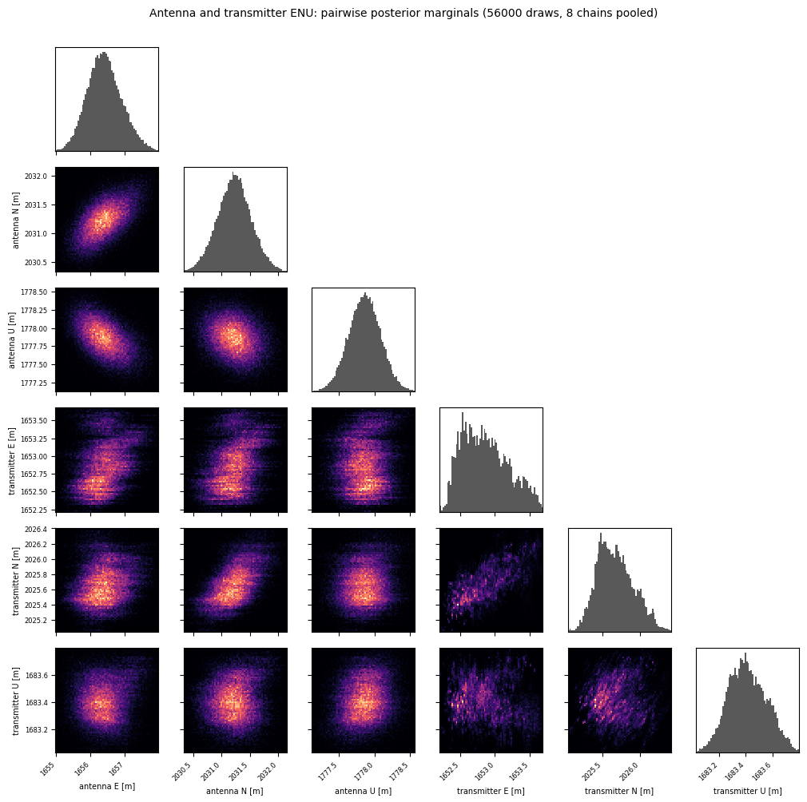

```
Posterior correlation matrix  (ant = antenna, tx = transmitter):
            ant E    ant N    ant U     tx E     tx N     tx U
ant E       1.000    0.577   -0.510    0.332    0.199    0.143
ant N       0.577    1.000   -0.238    0.330    0.562    0.134
ant U      -0.510   -0.238    1.000    0.043    0.108    0.176
tx E        0.332    0.330    0.043    1.000    0.681   -0.145
tx N        0.199    0.562    0.108    0.681    1.000    0.047
tx U        0.143    0.134    0.176   -0.145    0.047    1.000

Largest antenna-transmitter cross term: 0.562  (antenna N - transmitter N)
```

```python
if 'transmitter_e' in names:
    LBL = ['antenna E', 'antenna N', 'antenna U',
           'transmitter E', 'transmitter N', 'transmitter U']
    X = flat[:, [ai, ai + 1, ai + 2, ti, ti + 1, ti + 2]]
    ncorner = 6
    # A common range per coordinate so each diagonal shares the axis of its column.
    rngs = [(np.percentile(X[:, k], .1), np.percentile(X[:, k], 99.9)) for k in range(ncorner)]
    fig, axs = plt.subplots(ncorner, ncorner, figsize=(10.2, 10.2))
    for i in range(ncorner):
        for j in range(ncorner):
            ax = axs[i, j]
            if j > i:
                ax.axis('off')
                continue
            if i == j:
                ax.hist(X[:, i], bins=70, range=rngs[i], color='0.35', histtype='stepfilled')
                ax.set_yticks([])
            else:
                ax.hist2d(X[:, j], X[:, i], bins=70, cmap='magma',
                          range=[rngs[j], rngs[i]], rasterized=True)
                ax.set_ylim(*rngs[i])
            ax.set_xlim(*rngs[j])
            ax.ticklabel_format(useOffset=False, style='plain')
            ax.tick_params(labelsize=6)
            if i < ncorner - 1:
                ax.set_xticklabels([])
            else:
                ax.set_xlabel(LBL[j] + ' [m]', fontsize=7)
                for t in ax.get_xticklabels():
                    t.set_rotation(45)
                    t.set_ha('right')
            if j == 0 and i > 0:
                ax.set_ylabel(LBL[i] + ' [m]', fontsize=7)
            else:
                ax.set_yticklabels([])
    fig.suptitle('Antenna and transmitter ENU: pairwise posterior marginals '
                 '(%d draws, %d chains pooled)' % (X.shape[0], nchain), fontsize=10)
    plt.tight_layout(rect=[0, 0, 1, .975]); plt.show()

    C = np.corrcoef(X.T)
    # Short labels: the full ones make the row wider than the print page box.
    SHORT = ['ant E', 'ant N', 'ant U', 'tx E', 'tx N', 'tx U']
    print('Posterior correlation matrix  (ant = antenna, tx = transmitter):')
    print(' ' * 8 + ''.join('%9s' % l for l in SHORT))
    for i in range(ncorner):
        print('%-8s' % SHORT[i] + ''.join('%9.3f' % C[i, j] for j in range(ncorner)))
    print()
    print('Largest antenna-transmitter cross term: %.3f  (antenna N - transmitter N)'
          % np.abs(C[:3, 3:]).max())
```

## 3c. Does the likelihood couple images through shared SIFT features?

**Yes — but not for the cameras that need it most, and that is the explanation for 2159.**

The joint objective *does* carry tie-point terms. 3,200 landmark 3-D positions are sampled as free parameters, and each camera's likelihood includes the reprojection residual of every landmark it observes (11,261 observations, Student-t with a 4 px scale). Cameras are therefore coupled **through shared landmark positions** — a well-constrained camera and a poorly-constrained one that observe the same landmark do pull on each other. There are no explicit epipolar terms in the sampler; the coupling is via shared structure, which is the standard bundle-adjustment formulation and is the mechanism being asked about.

**The catch:** 12 of the 29 cameras contribute **zero** observations, including every one of the six transmitter-era cameras.

```python
with np.load(manifest['state_file']) as s:
    st_keys = [str(k) for k in s['keys']]
    oc = np.asarray(s['obs_cam'], int)
cnt = np.bincount(oc, minlength=len(st_keys))
zero = [k for k, c in zip(st_keys, cnt) if c == 0]
print(f'{len(oc)} observations over {len(st_keys)} cameras')
print(f'cameras with ZERO feature observations: {len(zero)} -> {zero}')
print()
print('observations per camera:')
for i in np.argsort(cnt):
    flag = '   <-- no cross-image constraint' if cnt[i] == 0 else ''
    print(f'  {st_keys[i]:>6}: {cnt[i]:6d}{flag}')
```

```
11261 observations over 29 cameras
cameras with ZERO feature observations: 12 -> ['2209', '2210', '2211', '2214', '2232', '2245', '2159', '2171', '2199', '2203', '2172', '2198']

observations per camera:
    2198:      0   <-- no cross-image constraint
    2203:      0   <-- no cross-image constraint
    2199:      0   <-- no cross-image constraint
    2171:      0   <-- no cross-image constraint
    2159:      0   <-- no cross-image constraint
    2245:      0   <-- no cross-image constraint
    2232:      0   <-- no cross-image constraint
    2214:      0   <-- no cross-image constraint
    2211:      0   <-- no cross-image constraint
    2210:      0   <-- no cross-image constraint
    2209:      0   <-- no cross-image constraint
```

[output cut: 18 more lines]

So for camera **2159** the sampled likelihood reduces to: its own horizon, its own transmitter-pixel ray, and its own GPS/heading/altitude/focal priors. **Nothing ties its pose to any other camera.** And both of the terms it does have are nearly invariant along precisely the degenerate direction — sliding the camera back while lengthening the lens reproduces both the same skyline and the same bearing to the transmitter. A ridge with no cross-image constraint across it is exactly the geometry that produces the two separated modes in §1b.

**Is adding SIFT cross-image constraints plausible? Yes, and the data already exists.** `cv_features/sift_2159.npz` holds 3,487 keypoints, and the *deterministic* refit already used a matched 2159↔2199 pair (46 correspondences) as an epipolar term — it simply never entered the sampler's landmark structure. Two routes:

1. **Triangulate the existing matches into landmarks** and add them as ordinary observations. This fits the current model with no new likelihood terms — the machinery is already there and unused for these cameras.
2. **Add explicit epipolar residuals** between camera pairs, as the deterministic objective does. Avoids introducing new landmark parameters but adds a term type the sampler does not currently have.

Route 1 is the smaller change and directly targets the failure: a triangulated landmark shared with a well-constrained camera pins depth, which is the one thing 2159's current terms cannot do. Whether it *resolves* the bimodality is an empirical question — it would have to be tried — but it attacks the right degree of freedom, and the fact that 2159 recovered in the deterministic fit **only** once its feature pair was restored is direct evidence that this constraint is what pins that camera.

*Design question raised, not acted on — no re-run or reparameterisation here.*

## 4. Read-out

- The run **did not converge** and nothing in it is quotable as a posterior.
- The failure is concentrated, not diffuse: **camera focal lengths** are the stiffest class, with `cam2159_logf` the worst coordinate in the run.
- The **only block that mixes is the one sampled exactly** rather than by random walk, which is the clearest available evidence that the kernel is the bottleneck.
- Chains nevertheless **agree far better than Rhat can certify** — between-chain sd of the per-chain means is 0.07–0.30 m (antenna) and 0.11–0.27 m (transmitter) — and both posterior means land **inside** the existing deterministic brackets.
- The ~1 m vertical transmitter offset from the independent 2210/2211 pair **persists here too**, as it did in v4, the 2159 re-fit and the drop control.
- **2159's failure is multimodality, not slow mixing** (§1b), and the reason is structural: it carries **no cross-image feature constraint at all** (§3c).

No decision is taken here, and no re-run, reparameterisation or release was started.